# explore

Roland Krasser

2025-10-02

The explore package simplifies Exploratory Data Analysis (EDA). Get faster insights with less code!

explore package on Github: https://github.com/rolkra/explore

As the explore-functions fits well into the tidyverse, we load the dplyr-package as well.

```r
library(dplyr)
library(explore)
```

### Interactive data exploration

Explore your data set (in this case the iris data set) in one line of code:

```r
explore(iris)
```

A shiny app is launched, you can inspect individual variable, explore their relation to a target (binary / categorical / numerical), grow a decision tree or create a fully automated report of all variables with a few “mouse clicks”.

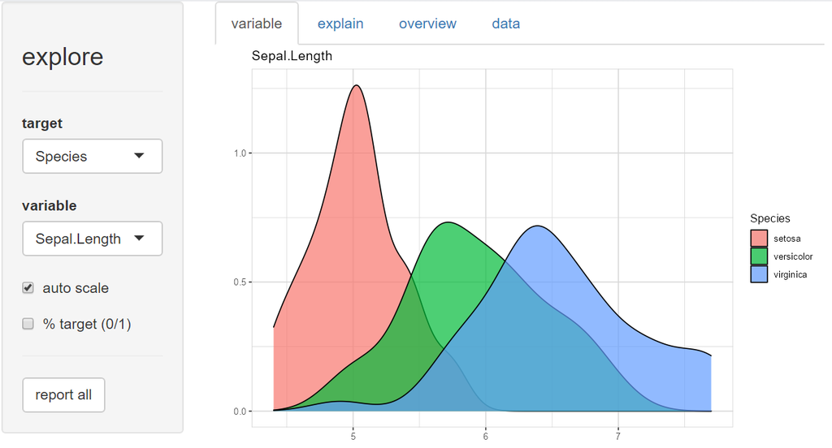

You can choose each variable containing as a target, that is binary (0/1, FALSE/TRUE or “no”/“yes”), categorical or numeric.

### Report variables

Create a rich HTML report of all variables with one line of code:

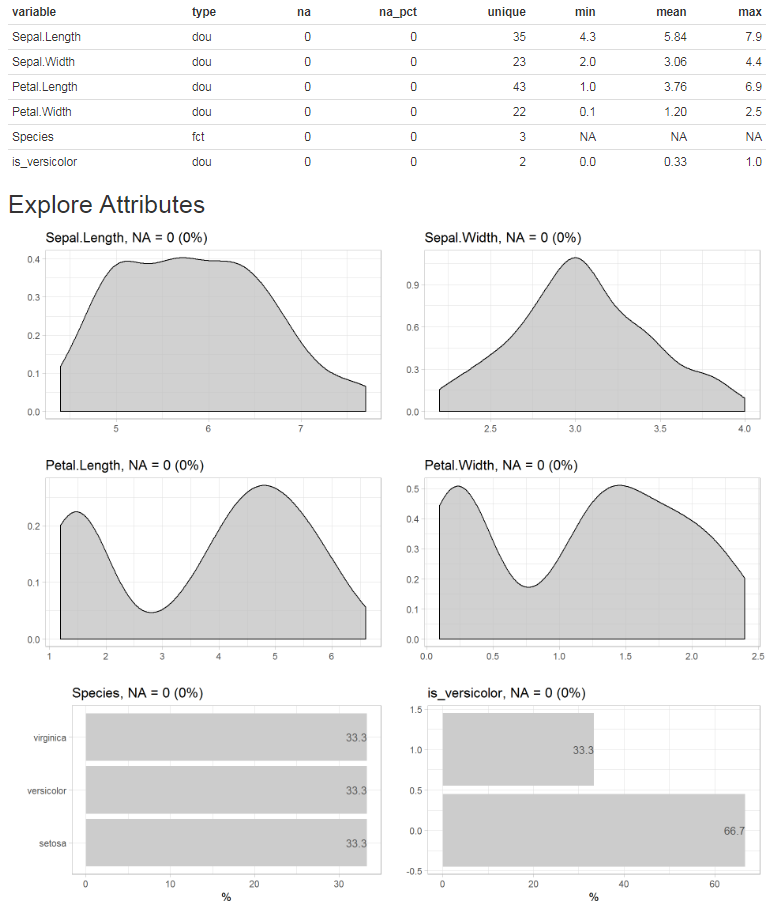

```r
# report of all variables
iris %>% report(output_file = "report.html", output_dir = tempdir())
```

Or you can simply add a target and create the report. In this case we use a binary target, but a categorical or numerical target would work as well.

```r
# report of all variables and their relationship with a binary target
iris$is_versicolor <- ifelse(iris$Species == "versicolor", 1, 0)
iris %>%
  report(output_file = "report.html",
         output_dir = tempdir(),
         target = is_versicolor)
```

If you use a binary target, the parameter *split = FALSE* (or `targetpct = TRUE`) will give you a different view on the data.

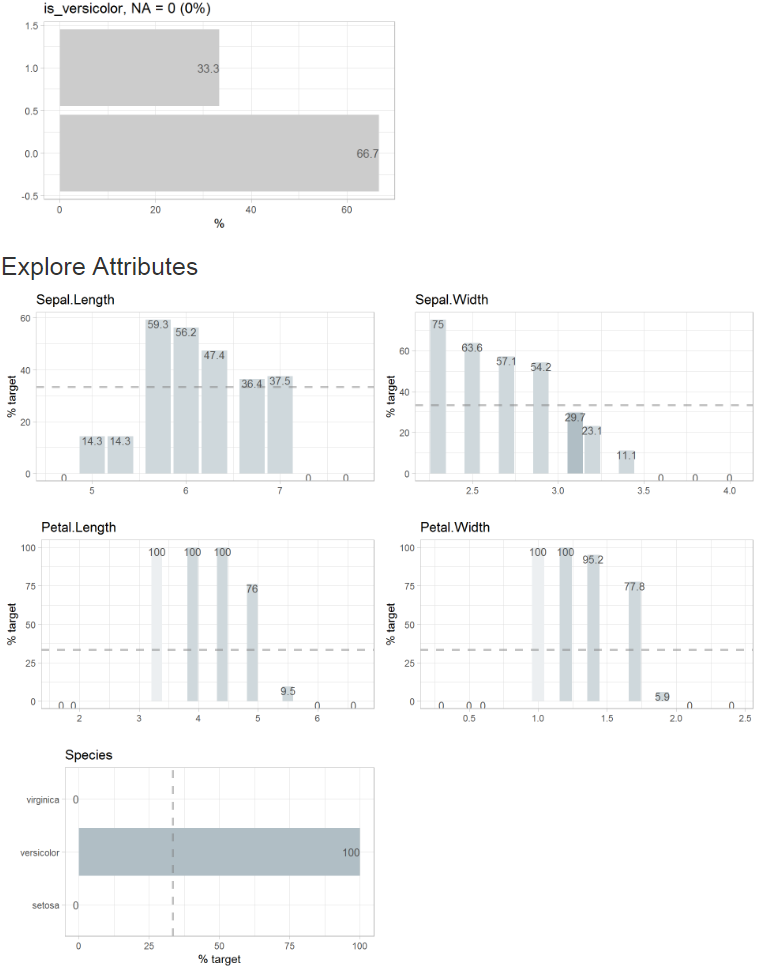

### Grow a decision tree

Grow a decision tree with one line of code:

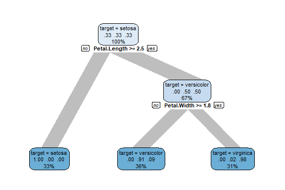

```r
iris %>% explain_tree(target = Species)
```

You can grow a decision tree with a binary target too.

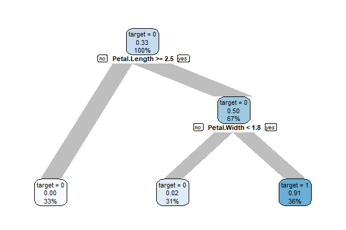

```r
iris$is_versicolor <- ifelse(iris$Species == "versicolor", 1, 0)
iris %>% select(-Species) %>% explain_tree(target = is_versicolor)
```

Or using a numerical target. The syntax stays the same.

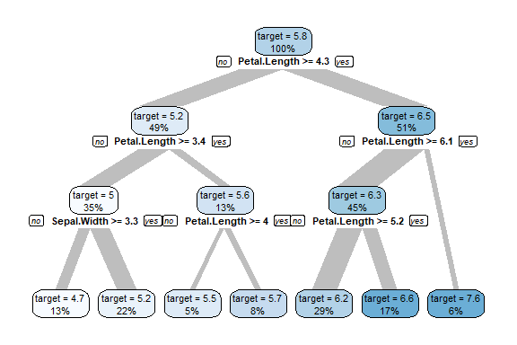

```r
iris %>% explain_tree(target = Sepal.Length)
```

You can control the growth of the tree using the parameters `maxdepth`, `minsplit` and `cp`.

To create other types of models use `explain_forest()`, `explain_xgboost()` and `explain_logreg()`.

### Explore dataset

Explore your table with one line of code to see which type of variables it contains.

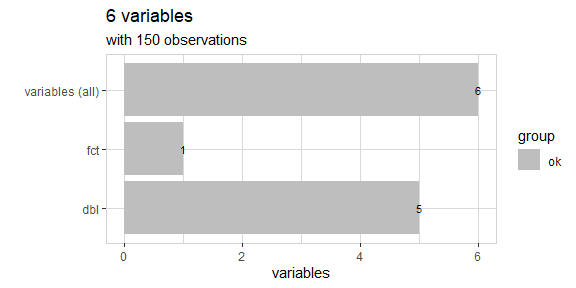

```r
iris %>% explore_tbl()
```

You can also use `describe_tbl()` if you just need the main facts without visualization.

```r
iris %>% describe_tbl()
```

```
#> 150 observations with 6 variables
#> 0 observations containing missings (NA)
#> 0 variables containing missings (NA)
#> 0 variables with no variance
```

### Explore variables

Explore a variable with one line of code. You don’t have to care if a variable is numerical or categorical.

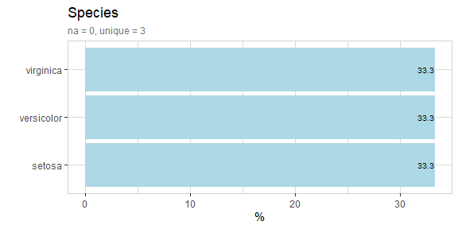

```r
iris %>% explore(Species)
```

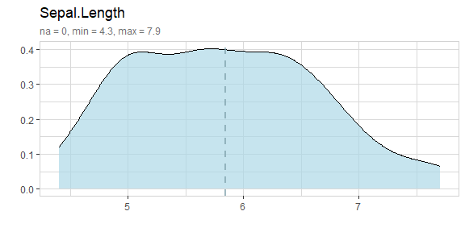

```r
iris %>% explore(Sepal.Length)
```

### Explore variables with a target

Explore a variable and its relationship with a binary target with one line of code. You don’t have to care if a variable is numerical or categorical.

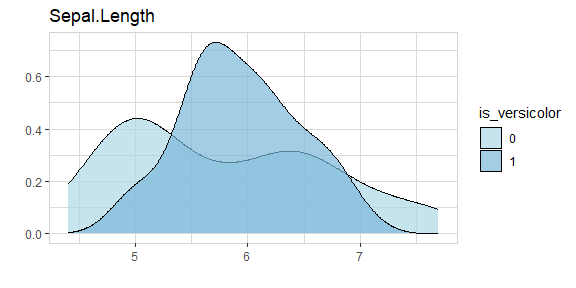

```r
iris %>% explore(Sepal.Length, target = is_versicolor)
```

Using split = FALSE will change the plot to %target:

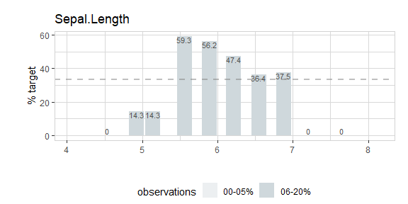

```r
iris %>% explore(Sepal.Length, target = is_versicolor, split = FALSE)
```

The target can have more than two levels:

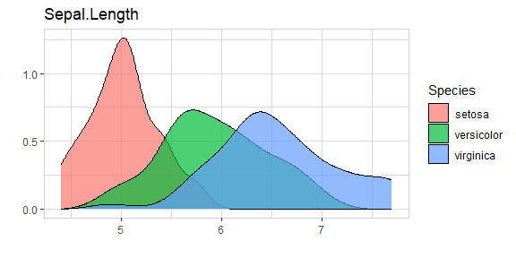

```r
iris %>% explore(Sepal.Length, target = Species)
```

Or the target can even be numeric:

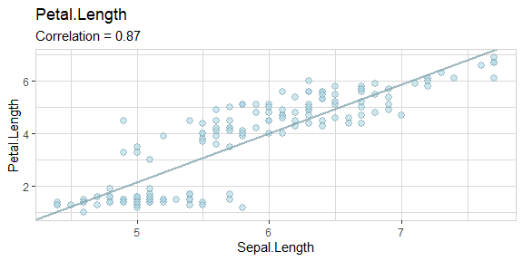

```r
iris %>% explore(Sepal.Length, target = Petal.Length)
```

### Explore multiple variables

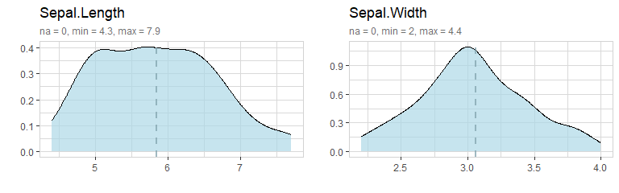

```r
iris %>%
  select(Sepal.Length, Sepal.Width) %>%
  explore_all()
```

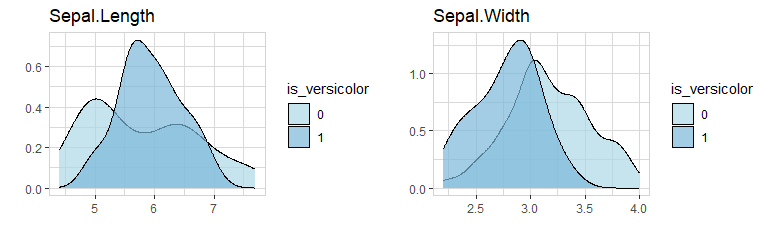

```r
iris %>%
  select(Sepal.Length, Sepal.Width, is_versicolor) %>%
  explore_all(target = is_versicolor)
```

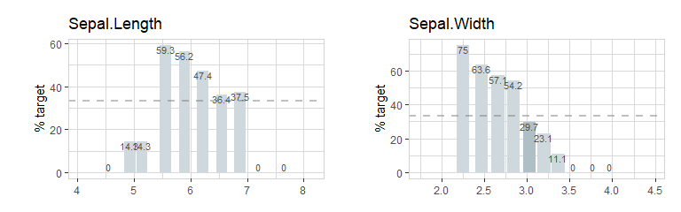

```r
iris %>%
  select(Sepal.Length, Sepal.Width, is_versicolor) %>%
  explore_all(target = is_versicolor, split = FALSE)
```

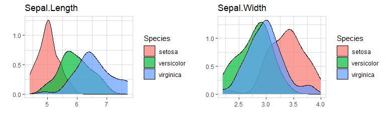

```r
iris %>%
  select(Sepal.Length, Sepal.Width, Species) %>%
  explore_all(target = Species)
```

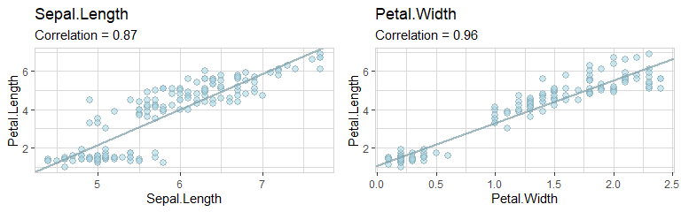

```r
iris %>%
  select(Sepal.Length, Petal.Width, Petal.Length) %>%
  explore_all(target = Petal.Length)
```

```r
data(iris)
```

To use a high number of variables with `explore_all()` in a RMarkdown-File, it is necessary to set a meaningful fig.width and fig.height in the junk. The function `total_fig_height()` helps to automatically set fig.height: `fig.height=total_fig_height(iris)`

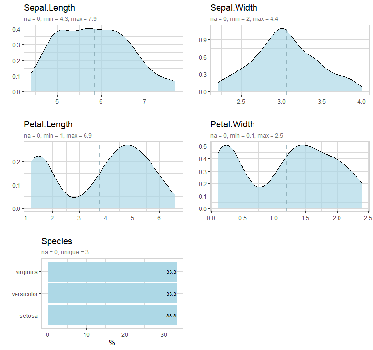

```r
iris %>%
  explore_all()
```

If you use a target: `fig.height=total_fig_height(iris, var_name_target = "Species")`

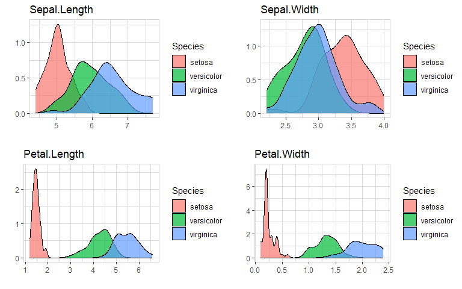

```r
iris %>% explore_all(target = Species)
```

You can control total_fig_height() by parameters ncols (number of columns of the plots) and size (height of 1 plot)